# Charity Project - Part 2

### 4. Data Preparation

1. Handling of Missing Values: Baesd upon the mosaic plots above the two of the three variables with missing values do not appear to be predictive. These variables are HINC and GENDER. We therefore exclude these variables from the data set. I have decided to keep the variable RFA_96 in the data set because it appears to have some predictive value. The mosaic plots provide evidence that different factor levels of RFA_96 have some predictive value. Lastly, we remove DAMT per the instruction notes.

```r
names(charity)
```

```
##  [1] "ID"       "DONR"     "DAMT"     "AGE"      "HOME"     "HINC"
##  [7] "GENDER"   "MEDAGE"   "MEDPPH"   "MEDHVAL"  "MEDINC"   "MEDEDUC"
## [13] "NUMPROM"  "NUMPRM12" "RAMNTALL" "NGIFTALL" "MAXRAMNT" "LASTGIFT"
## [19] "TDON"     "RFA_97"   "RFA_96"
```

```r
df1 = charity[,c(-1,-3, -4, -6, -7)]  #remove ID, DAMT, AGE, HINC, and GENDER.
names(df1)
```

```
##  [1] "DONR"     "HOME"     "MEDAGE"   "MEDPPH"   "MEDHVAL"  "MEDINC"
##  [7] "MEDEDUC"  "NUMPROM"  "NUMPRM12" "RAMNTALL" "NGIFTALL" "MAXRAMNT"
## [13] "LASTGIFT" "TDON"     "RFA_97"   "RFA_96"
```

2. Treatment of transformed variables added to the dataset: By trimming back the extreme values for the following numeric variables: MEDPPH, MEDAGE, and MEDINC, I was able to improve the distribution so that it becomes closer to the normal. Although I tried to trim all numeric variables to the 1st and 99th percentile I was not able to improve the normality of all of them. Therefore, we proceed with the three new variables MEDPPH_TRIM, MEDAGE_TRIM, and MEDINC_TRIM, and remove the original columns from our new data frame, df_trim.

```r
# Create 1% and 99% trimmed variables to see if more info provided.
# MEDAGE, MEDPPH, MEDHVAL, MEDINC, MEDEDUC, NUMPROM, NUMPRM12, RAMNTALL, NGIFALL, MAXRAMNT, LASTGIFT, TDON

# create new data frame so can revert back to df1 as backup.
df_trim = df1

# function to trim the values <1st and >99th percentils back to the 1st and 99th percentile values respectively.
fun <- function(x){
    quantiles <- quantile( x, c(.01, .99 ) )
    x[ x < quantiles[1] ] <- quantiles[1]
    x[ x > quantiles[2] ] <- quantiles[2]
    x
}

# create new variables with _TRIM appended at end.
df_trim$MEDPPH_TRIM    = fun( df_trim$MEDPPH )
df_trim$MEDHVAL_TRIM   = fun( df_trim$MEDHVAL )
df_trim$MEDEDUC_TRIM   = fun( df_trim$MEDEDUC )
df_trim$MEDAGE_TRIM    = fun( df_trim$MEDAGE )
df_trim$MEDINC_TRIM    = fun( df_trim$MEDINC )
df_trim$NUMPROM_TRIM   = fun( df_trim$NUMPROM )
df_trim$NUMPRM12_TRIM  = fun( df_trim$NUMPRM12 )
df_trim$MAXRAMNT_TRIM  = fun( df_trim$MAXRAMNT )
df_trim$RAMNTALL_TRIM  = fun( df_trim$RAMNTALL )
df_trim$LASTGIFT_TRIM  = fun( df_trim$LASTGIFT )
df_trim$NGIFTALL_TRIM  = fun( df_trim$NGIFTALL )
df_trim$TDON_TRIM      = fun( df_trim$TDON )
head(df_trim)
```

```
##   DONR HOME MEDAGE MEDPPH MEDHVAL MEDINC MEDEDUC NUMPROM NUMPRM12 RAMNTALL
## 1    0    1     45    180     313    195     120      34       14       53
## 2    0    0     38    118    1131    323     160      53       13       68
## 3    0    1     44    225    1518    728     160      18       13       20
## 4    0    1     32    247     857    501     140      43       14       84
## 5    0    1     42    208     440    236     120      55       12      172
## 6    0    0     39    266     580    202     120      23       11       35
##   NGIFTALL MAXRAMNT LASTGIFT TDON RFA_97 RFA_96 MEDPPH_TRIM MEDHVAL_TRIM
## 1        6       12       10   16    L4E    A4E         180          313
## 2        8       15       15   17    L2F    A2F         118         1131
## 3        2       15       15   18    L2F    N2F         225         1518
## 4        7       15       10   16    L4F    A4F         247          857
## 5       16       15       11   22    L2E    S2E         208          440
## 6        3       20       20   15    L2F    A1E         266          580
##   MEDEDUC_TRIM MEDAGE_TRIM MEDINC_TRIM NUMPROM_TRIM NUMPRM12_TRIM
## 1          120          45         195           34            14
## 2          160          38         323           53            13
## 3          160          44         728           18            13
## 4          140          32         501           43            14
## 5          120          42         236           55            12
## 6          120          39         202           23            11
##   MAXRAMNT_TRIM RAMNTALL_TRIM LASTGIFT_TRIM NGIFTALL_TRIM TDON_TRIM
## 1            12            53            10             6        16
## 2            15            68            15             8        17
## 3            15            20            15             2        18
## 4            15            84            10             7        16
## 5            15           172            11            16        22
## 6            20            35            20             3        15
```

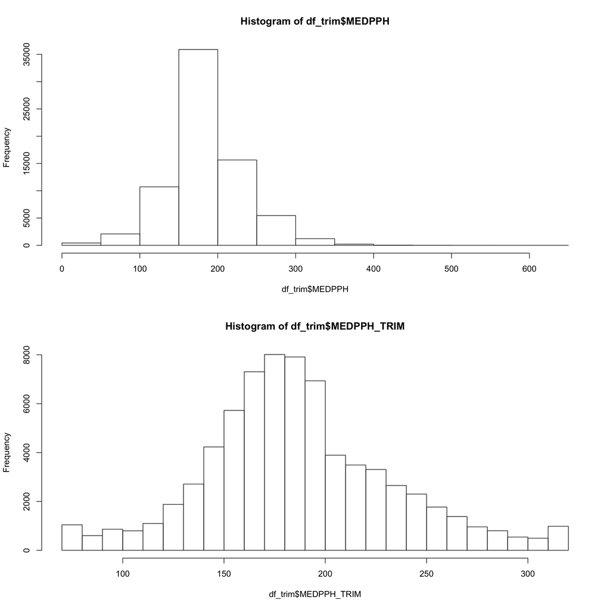

```r
par(mfrow=c(2,1))
hist(df_trim$MEDPPH)
hist(df_trim$MEDPPH_TRIM)  # looks more normal - good.
```

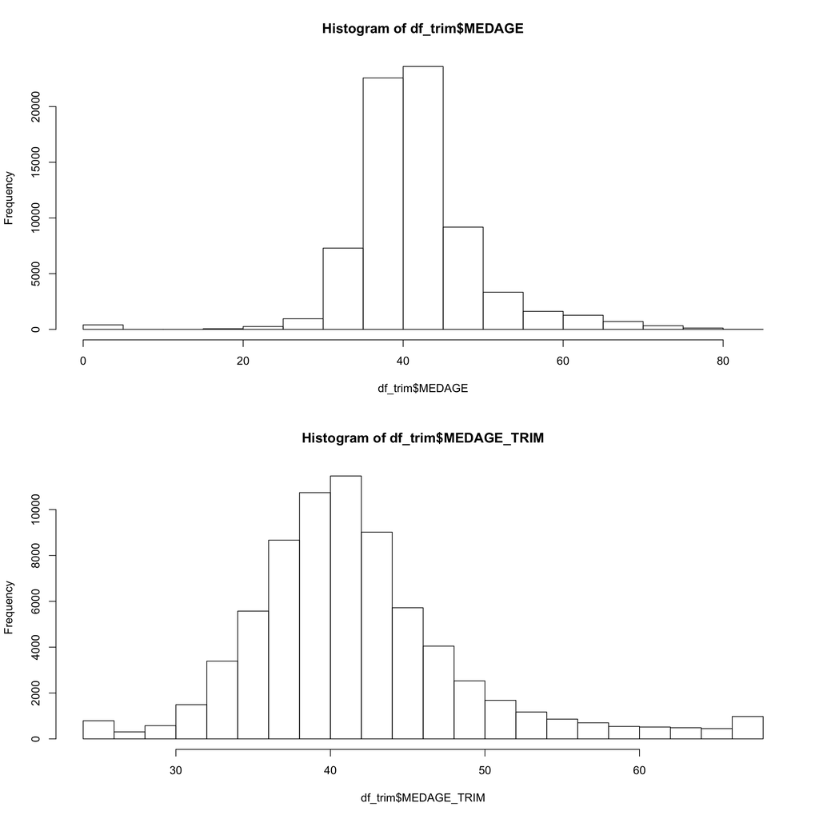

```r
par(mfrow=c(2,1))
hist(df_trim$MEDAGE)
hist(df_trim$MEDAGE_TRIM)  # looks more normal - good.
```

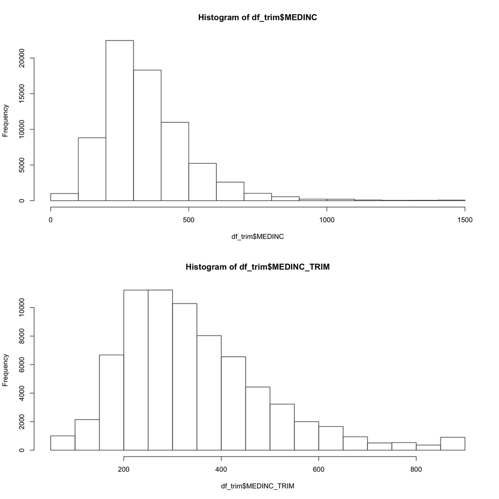

```r
par(mfrow=c(2,1))
hist(df_trim$MEDINC)
hist(df_trim$MEDINC_TRIM)  # looks slightly more normal - ok to include.
```

```r
# # columns below were not altered in anyway since either normality was not improved, or the outliers appeared to be valid.

# par(mfrow=c(2,1))
# hist(df_trim$RAMNTALL)
# hist(df_trim$RAMNTALL_TRIM) # data still skewed, but looks slighly more normal. however, related to dollar amounts given. do not want to include trimmed value.
#
# par(mfrow=c(2,1))
# hist(df_trim$MAXRAMNT)
# hist(df_trim$MAXRAMNT_TRIM)  # leaving as is. normal for maxramnt to be zero so dont want to exclude
#
# par(mfrow=c(2,1))
# hist(df_trim$MEDHVAL)
# hist(df_trim$MEDHVAL_TRIM) # don't include this one. no noticeable difference.
#
# par(mfrow=c(2,1))
# hist(df_trim$MEDEDUC)
# hist(df_trim$MEDEDUC_TRIM) # don't include this one. no noticeable difference.
#
# par(mfrow=c(2,1))
# hist(df_trim$NUMPROM)
# hist(df_trim$NUMPROM_TRIM) # data still skewed. leave original vals for now.
#
# par(mfrow=c(2,1))
# hist(df_trim$NUMPRM12)
# hist(df_trim$NUMPRM12_TRIM) # don't include this one. no noticeable difference.
#
# par(mfrow=c(2,1))
# hist(df_trim$LASTGIFT)
# hist(df_trim$LASTGIFT_TRIM) # leaving as is. normal for lastgift to be zero so dont want to exclude
#
# par(mfrow=c(2,1))
# hist(df_trim$NGIFTALL)
# hist(df_trim$NGIFTALL_TRIM)  # leave as is. not a noticeable enough improvement in normality.
#
# par(mfrow=c(2,1))
# hist(df_trim$TDON)
# hist(df_trim$TDON_TRIM)  # leave as is. not a noticeable enough improvement in normality.
```

```r
# include 3 new trimmed variables into new data frame 'df2'
names(df_trim)
```

```
##  [1] "DONR"          "HOME"          "MEDAGE"        "MEDPPH"
##  [5] "MEDHVAL"       "MEDINC"        "MEDEDUC"       "NUMPROM"
##  [9] "NUMPRM12"      "RAMNTALL"      "NGIFTALL"      "MAXRAMNT"
## [13] "LASTGIFT"      "TDON"          "RFA_97"        "RFA_96"
## [17] "MEDPPH_TRIM"   "MEDHVAL_TRIM"  "MEDEDUC_TRIM"  "MEDAGE_TRIM"
## [21] "MEDINC_TRIM"   "NUMPROM_TRIM"  "NUMPRM12_TRIM" "MAXRAMNT_TRIM"
## [25] "RAMNTALL_TRIM" "LASTGIFT_TRIM" "NGIFTALL_TRIM" "TDON_TRIM"
```

```r
df_trim_final = df_trim[,c(17,20,21)]
names(df_trim_final)
```

```
## [1] "MEDPPH_TRIM" "MEDAGE_TRIM" "MEDINC_TRIM"
```

```r
df2 = cbind(df1, df_trim_final)
df2 = df2[,c(-3,-4,-6)]
names(df2)
```

```
##  [1] "DONR"        "HOME"        "MEDHVAL"     "MEDEDUC"     "NUMPROM"
##  [6] "NUMPRM12"    "RAMNTALL"    "NGIFTALL"    "MAXRAMNT"    "LASTGIFT"
## [11] "TDON"        "RFA_97"      "RFA_96"      "MEDPPH_TRIM" "MEDAGE_TRIM"
## [16] "MEDINC_TRIM"
```

```r
str(df2)
```

```
## 'data.frame':    71700 obs. of  16 variables:
##  $ DONR       : Factor w/ 2 levels "0","1": 1 1 1 1 1 1 1 1 1 1 ...
##  $ HOME       : Factor w/ 2 levels "0","1": 2 1 2 2 2 1 1 1 2 2 ...
##  $ MEDHVAL    : int  313 1131 1518 857 440 580 678 1044 871 5913 ...
##  $ MEDEDUC    : int  120 160 160 140 120 120 114 120 120 160 ...
##  $ NUMPROM    : int  34 53 18 43 55 23 14 24 56 32 ...
##  $ NUMPRM12   : int  14 13 13 14 12 11 8 12 13 12 ...
##  $ RAMNTALL   : num  53 68 20 84 172 35 15 39 115 44 ...
##  $ NGIFTALL   : int  6 8 2 7 16 3 1 5 6 5 ...
##  $ MAXRAMNT   : num  12 15 15 15 15 20 15 10 25 12 ...
##  $ LASTGIFT   : num  10 15 15 10 11 20 15 7 25 12 ...
##  $ TDON       : num  16 17 18 16 22 ...
##  $ RFA_97     : Factor w/ 14 levels "L1E","L1F","L1G",..: 12 5 5 13 4 5 2 8 3 8 ...
##  $ RFA_96     : Factor w/ 69 levels "A1D","A1E","A1F",..: 17 8 43 18 56 2 23 12 4 12 ...
##  $ MEDPPH_TRIM: num  180 118 225 247 208 266 288 198 236 183 ...
##  $ MEDAGE_TRIM: num  45 38 44 32 42 39 40 43 47 49 ...
##  $ MEDINC_TRIM: num  195 323 728 501 236 202 171 562 322 810 ...
```

3. Re-categorization of categorical variables: There is a lot of information compiled into the three character code variables: RFA_96 and RFA_97. These two variables covering a donor’s RFA status as of the 1996/1997 promotion date include a character for RECENCY, FREQUENCY, and AMOUNT. We have broken these two variables into five variables. Note that RECENCY_97 is not included as an additional variable because all donors in this column are ‘L’, i.e. lapsing donors.

```r
# add 5 new categorical variables in place of RFA_96 and RFA_97

#df2$RECENCY_97   = substr(df2$RFA_97,1,1)   #removed as only 1 factor found.
df2$FREQUENCY_97 = substr(df2$RFA_97,2,2)
df2$AMOUNT_97    = substr(df2$RFA_97,3,3)

df2$RECENCY_96   = substr(df2$RFA_96,1,1)
df2$FREQUENCY_96 = substr(df2$RFA_96,2,2)
df2$AMOUNT_96    = substr(df2$RFA_96,3,3)

# make the new variables factors
df2$FREQUENCY_97 = factor(df2$FREQUENCY_97)
df2$AMOUNT_97    = factor(df2$AMOUNT_97)
df2$RECENCY_96   = factor(df2$RECENCY_96)
df2$FREQUENCY_96 = factor(df2$FREQUENCY_96)
df2$AMOUNT_96    = factor(df2$AMOUNT_96)

names(df2)
```

```
##  [1] "DONR"         "HOME"         "MEDHVAL"      "MEDEDUC"
##  [5] "NUMPROM"      "NUMPRM12"     "RAMNTALL"     "NGIFTALL"
##  [9] "MAXRAMNT"     "LASTGIFT"     "TDON"         "RFA_97"
## [13] "RFA_96"       "MEDPPH_TRIM"  "MEDAGE_TRIM"  "MEDINC_TRIM"
## [17] "FREQUENCY_97" "AMOUNT_97"    "RECENCY_96"   "FREQUENCY_96"
## [21] "AMOUNT_96"
```

We also fill in the NA values for RECENTY_96, FREQUENCY_96, and AMOUNT_96. I assume that if no values are recorded then this means that the email recipient has a null value.

```r
summary(df2)
```

```
##  DONR      HOME         MEDHVAL          MEDEDUC         NUMPROM
##  0:68016   0:24267   Min.   :   0.0   Min.   :  0.0   Min.   :  4.00
##  1: 3684   1:47433   1st Qu.: 524.0   1st Qu.:120.0   1st Qu.: 30.00
##                      Median : 745.5   Median :120.0   Median : 49.00
##                      Mean   :1062.9   Mean   :128.6   Mean   : 48.51
##                      3rd Qu.:1205.0   3rd Qu.:140.0   3rd Qu.: 65.00
##                      Max.   :6000.0   Max.   :170.0   Max.   :194.00
##
##     NUMPRM12        RAMNTALL         NGIFTALL          MAXRAMNT
##  Min.   : 2.00   Min.   :  13.0   Min.   :  1.000   Min.   :   5.00
##  1st Qu.:11.00   1st Qu.:  43.0   1st Qu.:  4.000   1st Qu.:  14.00
##  Median :12.00   Median :  82.0   Median :  8.000   Median :  17.00
##  Mean   :12.94   Mean   : 107.6   Mean   :  9.883   Mean   :  19.88
##  3rd Qu.:13.00   3rd Qu.: 135.0   3rd Qu.: 14.000   3rd Qu.:  24.00
##  Max.   :64.00   Max.   :5674.9   Max.   :237.000   Max.   :1000.00
##
##     LASTGIFT            TDON           RFA_97          RFA_96
##  Min.   :   0.00   Min.   : 4.00   L1F    :22718   A1F    :17247
##  1st Qu.:  10.00   1st Qu.:16.00   L1G    : 9326   A1G    : 7246
##  Median :  15.00   Median :18.00   L2F    : 8255   A2F    : 4839
##  Mean   :  17.27   Mean   :18.38   L3E    : 5697   A1E    : 4102
##  3rd Qu.:  20.00   3rd Qu.:21.00   L2E    : 3997   F1F    : 3935
##  Max.   :1000.00   Max.   :27.00   L1E    : 3926   (Other):33502
##                                    (Other):17781   NA's   :  829
##   MEDPPH_TRIM     MEDAGE_TRIM     MEDINC_TRIM    FREQUENCY_97 AMOUNT_97
##  Min.   : 72.0   Min.   :25.99   Min.   : 81.0   1:35970      D: 5472
##  1st Qu.:159.0   1st Qu.:38.00   1st Qu.:237.0   2:15710      E:16488
##  Median :183.0   Median :41.00   Median :315.0   3:11430      F:35144
##  Mean   :186.8   Mean   :42.22   Mean   :345.1   4: 8590      G:14596
##  3rd Qu.:213.0   3rd Qu.:45.00   3rd Qu.:421.0
##  Max.   :318.0   Max.   :68.00   Max.   :898.0
##
##  RECENCY_96   FREQUENCY_96 AMOUNT_96
##  A   :46129   1   :35866   B   :    4
##  F   : 5483   2   :15877   C   :   39
##  L   :  383   3   :10865   D   : 5668
##  N   : 4041   4   : 8263   E   :16465
##  S   :14835   NA's:  829   F   :34374
##  NA's:  829                G   :14321
##                            NA's:  829
```

```r
df2$RECENCY_96   = factor(ifelse(is.na(df2$RECENCY_96),'None',df2$RECENCY_96))
df2$FREQUENCY_96 = factor(ifelse(is.na(df2$FREQUENCY_96),'None',df2$FREQUENCY_96))
df2$AMOUNT_96    = factor(ifelse(is.na(df2$AMOUNT_96),'None',df2$AMOUNT_96))

table(df2$RECENCY_96, df2$DONR)
```

```
##
##            0     1
##   1    43942  2187
##   2     5303   180
##   3      367    16
##   4     3856   185
##   5    13766  1069
##   None   782    47
```

```r
table(df2$FREQUENCY_96, df2$DONR)
```

```
##
##            0     1
##   1    34450  1416
##   2    15039   838
##   3    10147   718
##   4     7598   665
##   None   782    47
```

```r
table(df2$AMOUNT_96, df2$DONR)
```

```
##
##            0     1
##   1        3     1
##   2       36     3
##   3     5158   510
##   4    15409  1056
##   5    32824  1550
##   6    13804   517
##   None   782    47
```

```r
# To this point already removed ID, DAMT, AGE, HINC, GENDER, MEDAGE, MEDINC, MEDPPH. In addition remove RFA_96 and RFA_97.
# THese variables are not needed since we broke RFA_96 and RFA_97 into five new variables above.
# Create new data frame 'df3'.
names(df2)
```

```
##  [1] "DONR"         "HOME"         "MEDHVAL"      "MEDEDUC"
##  [5] "NUMPROM"      "NUMPRM12"     "RAMNTALL"     "NGIFTALL"
##  [9] "MAXRAMNT"     "LASTGIFT"     "TDON"         "RFA_97"
## [13] "RFA_96"       "MEDPPH_TRIM"  "MEDAGE_TRIM"  "MEDINC_TRIM"
## [17] "FREQUENCY_97" "AMOUNT_97"    "RECENCY_96"   "FREQUENCY_96"
## [21] "AMOUNT_96"
```

```r
df3 = df2[,c(-12,-13)]  # also remove RFA_96 and RFA_97.
names(df3)
```

```
##  [1] "DONR"         "HOME"         "MEDHVAL"      "MEDEDUC"
##  [5] "NUMPROM"      "NUMPRM12"     "RAMNTALL"     "NGIFTALL"
##  [9] "MAXRAMNT"     "LASTGIFT"     "TDON"         "MEDPPH_TRIM"
## [13] "MEDAGE_TRIM"  "MEDINC_TRIM"  "FREQUENCY_97" "AMOUNT_97"
## [17] "RECENCY_96"   "FREQUENCY_96" "AMOUNT_96"
```

### 5. Dataset Partitioning

In this next section we employ a hold-out test dataset for model validation and selection.

a & b. Creation of Hold-Out Test Set and Training Set In the R code below we take a sample of 25% of the observations in the dataset to form a hold-out test set. This data will be referred to as the test set for the remainder of the document. The remaining 75% form the training set. See R code below for creation of ch.train and ch.test. Note that df3 is the final version of the charity data frame.

```r
dim(df3) # 71700 x 19
```

```
## [1] 71700    19
```

```r
names(df3)
```

```
##  [1] "DONR"         "HOME"         "MEDHVAL"      "MEDEDUC"
##  [5] "NUMPROM"      "NUMPRM12"     "RAMNTALL"     "NGIFTALL"
##  [9] "MAXRAMNT"     "LASTGIFT"     "TDON"         "MEDPPH_TRIM"
## [13] "MEDAGE_TRIM"  "MEDINC_TRIM"  "FREQUENCY_97" "AMOUNT_97"
## [17] "RECENCY_96"   "FREQUENCY_96" "AMOUNT_96"
```

```r
smp.size = floor(0.75 * nrow(df3))
smp.size  # 53775 is the size of the training data set.
```

```
## [1] 53775
```

```r
set.seed(1)
train = sample(seq_len(nrow(df3)), size = smp.size)
test = -train

ch.train = df3[train,]
ch.test = df3[-train,]

dim(ch.train)  # 53775 19
```

```
## [1] 53775    19
```

```r
summary(ch.train)
```

```
##  DONR      HOME         MEDHVAL        MEDEDUC         NUMPROM
##  0:50979   0:18280   Min.   :   0   Min.   :  0.0   Min.   :  4.00
##  1: 2796   1:35495   1st Qu.: 523   1st Qu.:120.0   1st Qu.: 30.00
##                      Median : 746   Median :120.0   Median : 49.00
##                      Mean   :1061   Mean   :128.6   Mean   : 48.54
##                      3rd Qu.:1206   3rd Qu.:140.0   3rd Qu.: 65.00
##                      Max.   :6000   Max.   :170.0   Max.   :177.00
##
##     NUMPRM12        RAMNTALL         NGIFTALL         MAXRAMNT
##  Min.   : 2.00   Min.   :  15.0   Min.   : 1.000   Min.   :   5.00
##  1st Qu.:11.00   1st Qu.:  43.0   1st Qu.: 4.000   1st Qu.:  14.00
##  Median :12.00   Median :  82.0   Median : 8.000   Median :  17.00
##  Mean   :12.95   Mean   : 107.6   Mean   : 9.899   Mean   :  19.86
##  3rd Qu.:13.00   3rd Qu.: 135.0   3rd Qu.:14.000   3rd Qu.:  24.00
##  Max.   :55.00   Max.   :3986.0   Max.   :95.000   Max.   :1000.00
##
##     LASTGIFT            TDON        MEDPPH_TRIM     MEDAGE_TRIM
##  Min.   :   0.00   Min.   : 4.00   Min.   : 72.0   Min.   :25.99
##  1st Qu.:  10.00   1st Qu.:16.00   1st Qu.:159.0   1st Qu.:38.00
##  Median :  15.00   Median :18.00   Median :183.0   Median :41.00
##  Mean   :  17.26   Mean   :18.38   Mean   :186.8   Mean   :42.22
##  3rd Qu.:  20.00   3rd Qu.:21.00   3rd Qu.:213.0   3rd Qu.:45.00
##  Max.   :1000.00   Max.   :27.00   Max.   :318.0   Max.   :68.00
##
##   MEDINC_TRIM    FREQUENCY_97 AMOUNT_97 RECENCY_96   FREQUENCY_96
##  Min.   : 81.0   1:26879      D: 4139   1   :34507   1   :26800
##  1st Qu.:236.0   2:11875      E:12351   2   : 4111   2   :12005
##  Median :315.0   3: 8571      F:26348   3   :  298   3   : 8189
##  Mean   :344.7   4: 6450      G:10937   4   : 3056   4   : 6169
##  3rd Qu.:420.0                          5   :11191   None:  612
##  Max.   :898.0                          None:  612
##
##  AMOUNT_96
##  1   :    3
##  2   :   26
##  3   : 4281
##  4   :12336
##  5   :25781
##  6   :10736
##  None:  612
```

```r
pct.donate.train = 2796/53775
pct.donate.train # 0.05199442
```

```
## [1] 0.05199442
```

```r
dim(ch.test)   # 17925 19
```

```
## [1] 17925    19
```

```r
summary(ch.test)
```

```
##  DONR      HOME         MEDHVAL        MEDEDUC         NUMPROM
##  0:17037   0: 5987   Min.   :   0   Min.   :  0.0   Min.   :  4.00
##  1:  888   1:11938   1st Qu.: 527   1st Qu.:120.0   1st Qu.: 30.00
##                      Median : 742   Median :120.0   Median : 49.00
##                      Mean   :1068   Mean   :128.8   Mean   : 48.42
##                      3rd Qu.:1205   3rd Qu.:140.0   3rd Qu.: 65.00
##                      Max.   :6000   Max.   :170.0   Max.   :194.00
##
##     NUMPRM12        RAMNTALL         NGIFTALL          MAXRAMNT
##  Min.   : 2.00   Min.   :  13.0   Min.   :  1.000   Min.   :   5.00
##  1st Qu.:11.00   1st Qu.:  44.0   1st Qu.:  4.000   1st Qu.:  14.00
##  Median :12.00   Median :  82.0   Median :  8.000   Median :  17.00
##  Mean   :12.92   Mean   : 107.4   Mean   :  9.835   Mean   :  19.94
##  3rd Qu.:13.00   3rd Qu.: 135.0   3rd Qu.: 14.000   3rd Qu.:  25.00
##  Max.   :64.00   Max.   :5674.9   Max.   :237.000   Max.   :1000.00
##
##     LASTGIFT           TDON        MEDPPH_TRIM   MEDAGE_TRIM
##  Min.   :  0.00   Min.   : 4.00   Min.   : 72   Min.   :25.99
##  1st Qu.: 10.00   1st Qu.:16.00   1st Qu.:159   1st Qu.:38.00
##  Median : 15.00   Median :18.00   Median :183   Median :41.00
##  Mean   : 17.29   Mean   :18.38   Mean   :187   Mean   :42.22
##  3rd Qu.: 20.00   3rd Qu.:21.00   3rd Qu.:213   3rd Qu.:45.00
##  Max.   :300.00   Max.   :27.00   Max.   :318   Max.   :68.00
##
##   MEDINC_TRIM    FREQUENCY_97 AMOUNT_97 RECENCY_96   FREQUENCY_96
##  Min.   : 81.0   1:9091       D:1333    1   :11622   1   :9066
##  1st Qu.:238.0   2:3835       E:4137    2   : 1372   2   :3872
##  Median :316.0   3:2859       F:8796    3   :   85   3   :2676
##  Mean   :346.2   4:2140       G:3659    4   :  985   4   :2094
##  3rd Qu.:421.0                          5   : 3644   None: 217
##  Max.   :898.0                          None:  217
##
##  AMOUNT_96
##  1   :   1
##  2   :  13
##  3   :1387
##  4   :4129
##  5   :8593
##  6   :3585
##  None: 217
```

```r
pct.donate.test = 888/17925
pct.donate.test # 0.04953975
```

```
## [1] 0.04953975
```

From the above summary() outputs we can see that the training set consists of 53775 observations (i.e. 75% of 71700) and 19 variables. The test set consists of the remaining 25% of observations, i.e. 17925 observations and 19 variables. Note that of the 19 variables one of which is the response variable, DONR. In the training sample there are 5.2% of observations with a positive response to mailing and in the testing data set 5.0% have a postive response.